### Initiation

```python
import pandas as pd
import random
import numpy as np

# Paramètres
n_clients = 500
professions = ['Ingénieur', 'Enseignant', 'Médecin', 'Consultant', 'Artisan']

# Génération de la base de données
data = {
    'ID client': range(1, n_clients + 1),
    'Âge': [random.randint(25, 60) for _ in range(n_clients)],
    'Sexe': [random.choice(['M', 'F']) for _ in range(n_clients)],
    'Revenu annuel': [random.randint(25000, 100000) for _ in range(n_clients)],
    'Taux d\'endettement (%)': [random.randint(0, 50) for _ in range(n_clients)],
    'Niveau de découvert': [random.randint(0, 5000) for _ in range(n_clients)],
    'Montant de découvert': [random.randint(0, 2000) for _ in range(n_clients)],
    'Crédit immobilier (oui/non)': [random.choice(['Oui', 'Non']) for _ in range(n_clients)],
    'Encours crédit à la consommation': [random.randint(0, 30000) for _ in range(n_clients)],
    'Encours placement': [random.randint(0, 10000) for _ in range(n_clients)],
    'Encours épargne': [random.randint(0, 20000) for _ in range(n_clients)],
    'Encours compte courant': [random.randint(0, 30000) for _ in range(n_clients)],
    'Encours crédit immobilier': [random.randint(0, 200000) for _ in range(n_clients)],
    'Compte épargne (oui/non)': [random.choice(['Oui', 'Non']) for _ in range(n_clients)],
    'Compte placement (oui/non)': [random.choice(['Oui', 'Non']) for _ in range(n_clients)],
    'Compte courant (oui/non)': [random.choice(['Oui', 'Non']) for _ in range(n_clients)],
    'Carte (oui/non)': [random.choice(['Oui', 'Non']) for _ in range(n_clients)],
    'Assurance (oui/non)': [random.choice(['Oui', 'Non']) for _ in range(n_clients)],
    'Profession': [random.choice(professions) for _ in range(n_clients)],
}

# Création de la variable cible déséquilibrée
data['Variable cible'] = [1] * 50 + [0] * 450
random.shuffle(data['Variable cible'])

# Ajustement des montants, introduction de valeurs manquantes et aberrantes
for i in range(n_clients):
    # Valeurs manquantes pour l'âge (environ 5 % des valeurs)
    if random.random() < 0.05:
        data['Âge'][i] = np.nan  # Valeur manquante pour l'âge

    # Valeurs aberrantes pour le revenu et les montants
    if random.random() < 0.05:  # Valeur aberrante pour le revenu
        data['Revenu annuel'][i] = random.randint(150000, 300000)
    else:
        data['Revenu annuel'][i] = random.randint(25000, 100000)

    data['Taux d\'endettement (%)'][i] = random.randint(0, 50)
    data['Niveau de découvert'][i] = random.randint(0, 5000)

    # Montant de découvert
    if data['Variable cible'][i] == 1:
        data['Montant de découvert'][i] = random.randint(500, 2000)
        data['Découvert (oui/non)'] = random.choice(['Oui', 'Non'])
    else:
        data['Montant de découvert'][i] = random.randint(0, 500)
        data['Découvert (oui/non)'] = 'Non'

    # Valeurs aberrantes pour les encours
    if random.random() < 0.05:
        data['Encours crédit à la consommation'][i] = random.randint(50000, 100000)
    else:
        data['Encours crédit à la consommation'][i] = random.randint(0, 30000)

    if random.random() < 0.05:
        data['Encours placement'][i] = random.randint(20000, 50000)
    else:
        data['Encours placement'][i] = random.randint(0, 10000)

    if random.random() < 0.05:
        data['Encours épargne'][i] = random.randint(30000, 60000)
    else:
        data['Encours épargne'][i] = random.randint(0, 20000)

    if random.random() < 0.05:
        data['Encours compte courant'][i] = random.randint(50000, 100000)
    else:
        data['Encours compte courant'][i] = random.randint(0, 30000)

    # Flux créditeur et débiteur
    data['Flux créditeur'] = [random.choice(['Oui', 'Non']) for _ in range(n_clients)]
    data['Flux débiteur'] = [random.choice(['Oui', 'Non']) for _ in range(n_clients)]
    data['Montant flux débiteur'] = [random.randint(0, 2000) for _ in range(n_clients)]
    data['Montant flux créditeur'] = [random.randint(0, 2000) for _ in range(n_clients)]

# Création du DataFrame
df = pd.DataFrame(data)

# Enregistrement dans un fichier CSV
df.to_csv('clients_bancaires.csv', index=False, encoding='utf-8')

print("Le fichier CSV a été créé avec succès.")
```

```
Le fichier CSV a été créé avec succès.
```

```python
df.head()
```

|  | ID client | Âge | Sexe | Revenu annuel | Taux d'endettement (%) | Niveau de découvert | Montant de découvert | Crédit immobilier (oui/non) | Encours crédit à la consommation | Encours placement | ... | Compte courant (oui/non) | Carte (oui/non) | Assurance (oui/non) | Profession | Variable cible | Découvert (oui/non) | Flux créditeur | Flux débiteur | Montant flux débiteur | Montant flux créditeur |
| --- | --- | --- | --- | --- | --- | --- | --- | --- | --- | --- | --- | --- | --- | --- | --- | --- | --- | --- | --- | --- | --- |
| 0 | 1 | 35.0 | F | 97939 | 47 | 2224 | 350 | Oui | 17207 | 2040 | ... | Non | Non | Oui | Consultant | 0 | Non | Oui | Oui | 453 | 1392 |
| 1 | 2 | 36.0 | F | 80740 | 36 | 4385 | 464 | Oui | 15704 | 2894 | ... | Non | Non | Non | Enseignant | 0 | Non | Oui | Oui | 616 | 382 |
| 2 | 3 | 60.0 | F | 85128 | 43 | 4221 | 183 | Non | 22282 | 3957 | ... | Non | Oui | Oui | Artisan | 0 | Non | Oui | Oui | 1880 | 1340 |
| 3 | 4 | NaN | M | 72015 | 48 | 5 | 297 | Oui | 788 | 41962 | ... | Oui | Non | Oui | Ingénieur | 0 | Non | Oui | Oui | 172 | 1344 |
| 4 | 5 | 46.0 | M | 53258 | 43 | 2752 | 275 | Non | 4859 | 1913 | ... | Oui | Oui | Non | Enseignant | 0 | Non | Non | Oui | 1969 | 1035 |

5 rows × 25 columns

```python
import pandas as pd
import numpy as np


# Étape 2 : Exploration des données
df.head() # Affiche les premières lignes
```

[output not shown]

5 rows × 25 columns

```python
df.info() # Affiche les informations sur les types de données
```

```
<class 'pandas.core.frame.DataFrame'>
RangeIndex: 500 entries, 0 to 499
Data columns (total 25 columns):
 #   Column                            Non-Null Count  Dtype
---  ------                            --------------  -----
 0   ID client                         500 non-null    int64
 1   Âge                               476 non-null    float64
 2   Sexe                              500 non-null    object
 3   Revenu annuel                     500 non-null    int64
 4   Taux d'endettement (%)            500 non-null    int64
 5   Niveau de découvert               500 non-null    int64
 6   Montant de découvert              500 non-null    int64
 7   Crédit immobilier (oui/non)       500 non-null    object
 8   Encours crédit à la consommation  500 non-null    int64
 9   Encours placement                 500 non-null    int64
```

[output cut: 17 more lines]

```python
df.describe() # Affiche des statistiques descriptives
```

|  | ID client | Âge | Revenu annuel | Taux d'endettement (%) | Niveau de découvert | Montant de découvert | Encours crédit à la consommation | Encours placement | Encours épargne | Encours compte courant | Encours crédit immobilier | Variable cible | Montant flux débiteur | Montant flux créditeur |
| --- | --- | --- | --- | --- | --- | --- | --- | --- | --- | --- | --- | --- | --- | --- |
| count | 500.000000 | 476.000000 | 500.000000 | 500.000000 | 500.000000 | 500.000000 | 500.000000 | 500.000000 | 500.000000 | 500.000000 | 500.000000 | 500.0000 | 500.000000 | 500.000000 |
| mean | 250.500000 | 41.802521 | 68240.518000 | 24.304000 | 2439.034000 | 355.704000 | 18280.032000 | 6668.452000 | 11854.140000 | 17875.328000 | 98158.572000 | 0.1000 | 1020.762000 | 994.956000 |
| std | 144.481833 | 10.519900 | 34468.397496 | 14.916454 | 1455.121312 | 372.850806 | 16460.502566 | 7730.210134 | 9029.379481 | 14742.435821 | 58928.628575 | 0.3003 | 557.460691 | 588.622905 |
| min | 1.000000 | 25.000000 | 25467.000000 | 0.000000 | 4.000000 | 1.000000 | 8.000000 | 2.000000 | 12.000000 | 103.000000 | 8.000000 | 0.0000 | 3.000000 | 5.000000 |
| 25% | 125.750000 | 32.750000 | 45201.500000 | 11.000000 | 1096.750000 | 140.500000 | 8231.250000 | 2801.500000 | 5556.500000 | 7990.500000 | 46991.000000 | 0.0000 | 536.000000 | 488.500000 |
| 50% | 250.500000 | 42.000000 | 65928.000000 | 24.500000 | 2478.000000 | 273.500000 | 15668.000000 | 5384.500000 | 10950.000000 | 16572.000000 | 97284.500000 | 0.0000 | 1031.500000 | 974.500000 |
| 75% | 375.250000 | 50.250000 | 84380.500000 | 38.000000 | 3711.500000 | 415.000000 | 23150.750000 | 7910.000000 | 16424.000000 | 23276.250000 | 149892.500000 | 0.0000 | 1486.500000 | 1498.000000 |
| max | 500.000000 | 60.000000 | 288937.000000 | 50.000000 | 4971.000000 | 1953.000000 | 99955.000000 | 48938.000000 | 56776.000000 | 97408.000000 | 199289.000000 | 1.0000 | 1998.000000 | 2000.000000 |

La méthode `df.describe()` fournit un résumé statistique des colonnes numériques de ton DataFrame. Voici comment lire et interpréter les résultats de cette méthode :

### Résumé des éléments de `df.describe()`

1. **count** : Le nombre total de valeurs non nulles dans la colonne. Cela te donne une idée de la quantité de données disponibles.
2. **mean** : La moyenne des valeurs dans la colonne. C’est un bon indicateur de la tendance centrale.
3. **std** : L'écart type, qui mesure la dispersion des valeurs par rapport à la moyenne. Un écart type élevé indique que les valeurs sont très dispersées.
4. **min** : La valeur minimale de la colonne.
5. **25%** (1er quartile) : 25 % des valeurs sont inférieures à ce chiffre. Cela donne une idée de la distribution des données.
6. **50%** (médiane ou 2e quartile) : La valeur qui sépare la moitié supérieure de la moitié inférieure des données.
7. **75%** (3e quartile) : 75 % des valeurs sont inférieures à cette valeur. Cela aide à comprendre la distribution supérieure des données.
8. **max** : La valeur maximale dans la colonne.

### Exemple de lecture

Supposons que tu aies ce résultat pour une colonne "Revenu annuel" :

```
        Revenu annuel
count      500.000000
mean      55342.250000
std       15583.895732
min       25000.000000
25%       43300.000000
50%       55000.000000
75%       67000.000000
max       100000.000000
```

- **count** : Il y a 500 enregistrements (valeurs non nulles) pour le revenu annuel.
- **mean** : La moyenne des revenus est de 55 342,25.
- **std** : L'écart type est de 15 583,90, ce qui signifie que les revenus varient considérablement autour de la moyenne.
- **min** : Le revenu le plus bas est de 25 000.
- **25%** : 25 % des clients ont un revenu inférieur à 43 300.
- **50%** : La médiane est de 55 000, ce qui indique que la moitié des clients gagnent moins que cela.
- **75%** : 75 % des clients gagnent moins de 67 000.
- **max** : Le revenu le plus élevé est de 100 000.

### Conclusion

En utilisant `df.describe()`, tu obtiens un aperçu rapide des caractéristiques statistiques de tes données, ce qui peut t'aider à détecter des valeurs aberrantes, à comprendre la répartition des valeurs et à identifier des tendances. Si tu as besoin d'une analyse plus approfondie ou de visualisations, tu peux envisager d'utiliser des bibliothèques comme `matplotlib` ou `seaborn`.

Si tu as d'autres questions ou souhaites explorer davantage, fais-le moi savoir !

```python
# Étape 3 : Gestion des valeurs manquantes
# Affiche le nombre de valeurs manquantes par colonne
missing_values = df.isnull().sum()
print("Valeurs manquantes par colonne :")
print(missing_values[missing_values > 0])
```

[output not shown]

```python
# Imputation simple (par exemple, avec la moyenne pour les colonnes numériques)
df['Âge'].fillna(df['Âge'].median(), inplace=True)  # Impute la médiane pour l'âge
```

L'imputation des valeurs manquantes est une étape importante dans la préparation des données, car les valeurs manquantes peuvent fausser les analyses et les modèles. Voici pourquoi nous utilisons la médiane pour imputer les valeurs manquantes de la colonne "Âge" :

### Pourquoi utiliser la médiane pour l'imputation ?

1. **Robustesse aux valeurs aberrantes** :
   - La médiane est moins sensible aux valeurs extrêmes que la moyenne. Par exemple, si la majorité des âges sont autour de 30-40 ans, mais qu'il y a quelques individus très âgés (par exemple, 90 ans), cela peut tirer la moyenne vers le haut. La médiane, en revanche, restera plus représentative des âges "typicals".
2. **Représentation de la tendance centrale** :
   - La médiane représente le point central de la distribution des âges, ce qui en fait une bonne estimation des valeurs manquantes si la distribution des âges est symétrique.
3. **Simplicité et rapidité** :
   - L'imputation par la médiane est simple à mettre en œuvre et rapide à calculer. Cela en fait une méthode pratique, surtout dans les ensembles de données volumineux.

### Autres méthodes d'imputation

Il existe plusieurs méthodes d'imputation, et le choix dépend du contexte :

- **Moyenne** : Souvent utilisée pour des distributions symétriques sans valeurs aberrantes.
- **Mode** : Utile pour les variables catégorielles ou lorsque la distribution est très asymétrique.
- **Imputation par régression** : Utilise les autres variables pour prédire les valeurs manquantes.
- **Imputation par interpolation** : Pour des séries chronologiques, on peut interpoler les valeurs manquantes.
- **Imputation multiple** : Crée plusieurs ensembles de données imputés pour capturer l'incertitude autour des valeurs manquantes.

### Conclusion

Dans ce cas, l'utilisation de la médiane pour imputer les âges est souvent une bonne pratique, surtout si les âges présentent une distribution potentiellement asymétrique ou si des valeurs aberrantes sont présentes. Si tu as des questions supplémentaires ou si tu souhaites explorer d'autres méthodes d'imputation, fais-le moi savoir !

## Pour déterminer si la distribution de l'âge est potentiellement asymétrique ou symétrique, tu peux utiliser plusieurs méthodes d'analyse visuelle et statistique. Voici quelques-unes des approches les plus courantes :

### 1. Visualisation des données

# Un histogramme montre la fréquence des âges dans des intervalles. Si la distribution est symétrique, l'histogramme aura une forme en cloche. Si elle est asymétrique, il sera décalé vers la droite (asymétrie positive) ou vers la gauche (asymétrie négative).

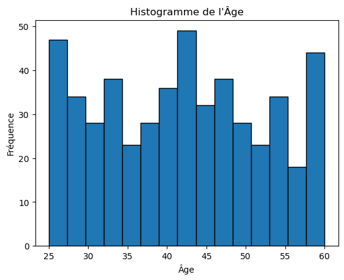

```python
import matplotlib.pyplot as plt

plt.hist(df['Âge'].dropna(), bins=15, edgecolor='black')
plt.title('Histogramme de l\'Âge')
plt.xlabel('Âge')
plt.ylabel('Fréquence')
plt.show()
```

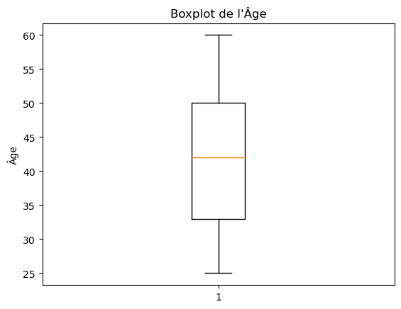

```python
#### Boîte à moustaches (Boxplot)
# Un boxplot montre la médiane, les quartiles et les valeurs aberrantes. Si la boîte est décalée vers le bas ou vers le haut, cela indique une asymétrie.

plt.boxplot(df['Âge'].dropna())
plt.title('Boxplot de l\'Âge')
plt.ylabel('Âge')
plt.show()
```

```python
### 2. Mesures statistiques

#### Asymétrie (Skewness)
# La mesure de l'asymétrie quantifie le degré d'asymétrie de la distribution. Un skewness proche de 0 indique une distribution symétrique, un skewness positif indique une asymétrie à droite et un skewness négatif indique une asymétrie à gauche.

skewness = df['Âge'].dropna().skew()
print("Asymétrie (Skewness) :", skewness)
```

```
Asymétrie (Skewness) : 0.08359527813503333
```

```python
#### Kurtosis
##La kurtosis mesure la "pointedness" de la distribution. Cela peut également donner des indices sur la forme de la distribution. Une kurtosis élevée pourrait indiquer une distribution avec des queues plus lourdes.

kurtosis = df['Âge'].dropna().kurt()
print("Kurtosis :", kurtosis)
```

```
Kurtosis : -1.1064319312505335
```

```python
### 3. Tests statistiques

#### Test de normalité
#Des tests tels que le test de Shapiro-Wilk ou le test de Kolmogorov-Smirnov peuvent être utilisés pour vérifier si les données suivent une distribution normale.


from scipy import stats

shapiro_test = stats.shapiro(df['Âge'].dropna())
print("Test de Shapiro-Wilk : ", shapiro_test)
```

```
Test de Shapiro-Wilk :  ShapiroResult(statistic=0.9561948776245117, pvalue=4.998618879925587e-11)
```

### Interprétation des résultats

- **Histogramme et Boxplot** : Visuellement, observe la forme de la distribution.
- **Skewness** :
  - Si (-0.5 < skewness < 0.5), la distribution est considérée comme symétrique.
  - Si (0.5 < skewness < 1) ou (-1 < skewness < -0.5), la distribution est modérément asymétrique.
  - Si (skewness > 1) ou (skewness < -1), la distribution est fortement asymétrique.
- **Kurtosis** : Une kurtosis proche de 0 indique une distribution normale. Les valeurs positives indiquent des queues plus lourdes, et les valeurs négatives indiquent des queues plus légères.
- **Tests de normalité** : Si la valeur p est inférieure à un seuil (souvent 0,05), cela indique que la distribution n'est pas normale.

### Conclusion

En combinant ces méthodes, tu peux obtenir une compréhension complète de la distribution de l'âge dans ta base de données. Si tu as besoin d'aide pour exécuter ces analyses ou interpréter les résultats, fais-le moi savoir !

```python
# Étape 4 : Gestion des valeurs aberrantes
# Exemple simple d'identification des valeurs aberrantes
def identify_outliers(column):
    Q1 = column.quantile(0.25)
    Q3 = column.quantile(0.75)
    IQR = Q3 - Q1
    return column[(column < (Q1 - 1.5 * IQR)) | (column > (Q3 + 1.5 * IQR))]

# Identifier les valeurs aberrantes dans le revenu
outliers_revenue = identify_outliers(df['Revenu annuel'])
print("Valeurs aberrantes dans le revenu :")
print(outliers_revenue)
```

```
Valeurs aberrantes dans le revenu :
23     153555
24     260036
51     178415
64     237701
70     154780
114    227538
133    232080
152    158802
154    240530
157    206183
174    235856
175    253163
210    235200
260    200429
268    264461
310    276425
381    193169
396    169033
402    192282
426    244750
434    277914
440    223981
Name: Revenu annuel, dtype: int64
```

Identifier les valeurs aberrantes est une étape importante dans la préparation des données, car elles peuvent influencer significativement les analyses et les modèles prédictifs. Voici quelques raisons pour lesquelles la méthode basée sur l'écart interquartile (IQR) est souvent utilisée pour identifier les valeurs aberrantes :

### 1. Robustesse aux valeurs extrêmes

- **IQR** mesure la dispersion des données en se basant sur les quartiles. Cela signifie qu'il est moins sensible aux valeurs extrêmes que d'autres méthodes comme la moyenne et l'écart type, qui peuvent être faussées par des valeurs aberrantes.

### 2. Définition claire des seuils

- La méthode IQR définit des seuils clairs pour identifier les valeurs aberrantes :
  - **Valeurs en dehors de [Q1 - 1.5 *IQR, Q3 + 1.5* IQR]** sont considérées comme aberrantes.
  - Cela permet de quantifier ce qui est considéré comme aberrant de manière standardisée.

### 3. Simplicité d'utilisation

- Le calcul de l'IQR est simple et rapide à mettre en œuvre. Il ne nécessite pas de distribution spécifique des données (comme une distribution normale) pour être efficace.

### 4. Utilisation généralisée

- La méthode IQR est largement utilisée dans la pratique statistique, ce qui la rend facilement compréhensible et applicable dans divers contextes. Les praticiens en data science et en statistiques sont souvent familiers avec cette approche.

### 5. Identification des points extrêmes

- Les valeurs aberrantes peuvent fournir des informations importantes sur des anomalies dans les données, des erreurs de mesure ou des cas particuliers. Parfois, ces points extrêmes sont significatifs et méritent d'être examinés plus en profondeur.

### Conclusion

L'utilisation de la méthode IQR pour identifier les valeurs aberrantes est une approche efficace, robuste et largement acceptée qui peut aider à améliorer la qualité des analyses et des modèles. Cela dit, il est également important d'examiner chaque valeur aberrante identifiée dans le contexte de l'ensemble des données, car certaines peuvent avoir une signification pertinente.

Si tu as d'autres questions ou souhaites explorer des méthodes alternatives pour identifier les valeurs aberrantes, fais-le moi savoir !

[figure not shown]

```python
import matplotlib.pyplot as plt

# Création d'un boxplot pour le revenu annuel
plt.figure(figsize=(8, 5))
plt.boxplot(df['Revenu annuel'].dropna())
plt.title('Boxplot du Revenu Annuel')
plt.ylabel('Revenu Annuel')
plt.grid(axis='y')
plt.show()
```

*Interprétation :*

La boîte représente l'IQR (intervalle interquartile) entre le 1er quartile (Q1) et le 3e quartile (Q3). La ligne à l'intérieur de la boîte indique la médiane. Les points en dehors des "moustaches" (qui s'étendent généralement à 1.5 fois l'IQR) sont considérés comme des valeurs aberrantes.

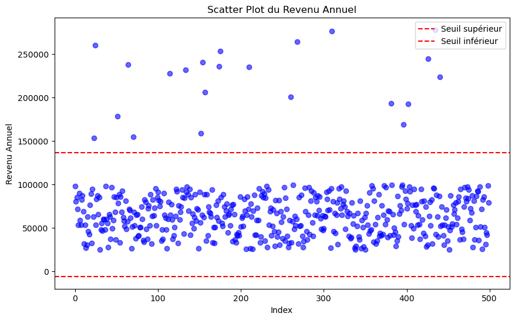

```python
plt.figure(figsize=(10, 6))
plt.scatter(df.index, df['Revenu annuel'], color='blue', alpha=0.6)
plt.title('Scatter Plot du Revenu Annuel')
plt.xlabel('Index')
plt.ylabel('Revenu Annuel')
plt.axhline(y=df['Revenu annuel'].quantile(0.75) + 1.5 * (df['Revenu annuel'].quantile(0.75) - df['Revenu annuel'].quantile(0.25)), color='red', linestyle='--', label='Seuil supérieur')
plt.axhline(y=df['Revenu annuel'].quantile(0.25) - 1.5 * (df['Revenu annuel'].quantile(0.75) - df['Revenu annuel'].quantile(0.25)), color='red', linestyle='--', label='Seuil inférieur')
plt.legend()
plt.show()
```

Interprétation :

Chaque point représente un enregistrement du revenu annuel. Les lignes rouges indiquent les seuils pour détecter les valeurs aberrantes (seuil supérieur et seuil inférieur). Les points au-dessus ou en dessous de ces lignes peuvent être considérés comme des valeurs aberrantes.

Conclusion Ces visualisations te permettent de voir rapidement où se trouvent les valeurs aberrantes dans tes données. Le boxplot est particulièrement efficace pour résumer la distribution des données, tandis que le scatter plot permet de voir les relations entre différentes variables.

Si tu as besoin d'aide pour interpréter les graphiques ou si tu souhaites d'autres types de visualisations, fais-le moi savoir !

```python
import pandas as pd
import matplotlib.pyplot as plt
import seaborn as sns
```

1. **Analyse des Relations entre Variables** :
   - Créer des scatter plots pour explorer les relations entre variables numériques.
   - Utiliser des heatmaps pour visualiser les corrélations entre les variables.

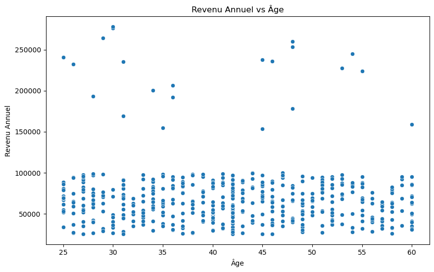

```python
# Étape 3 : Analyse des Relations entre Variables
plt.figure(figsize=(10, 6))
sns.scatterplot(x='Âge', y='Revenu annuel', data=df)
plt.title('Revenu Annuel vs Âge')
plt.xlabel('Âge')
plt.ylabel('Revenu Annuel')
plt.show()
```

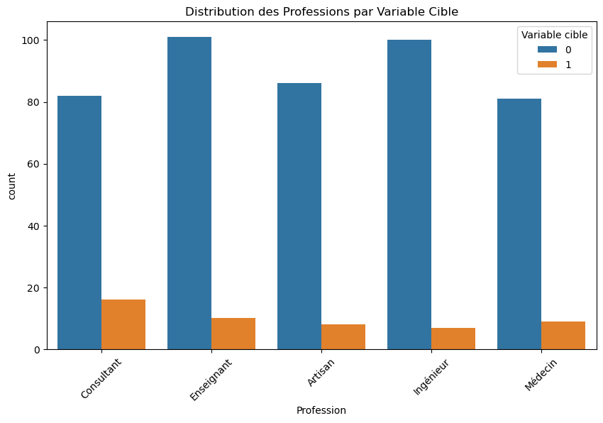

```python
# Étape 4 : Analyse des Variables Catégorielles
plt.figure(figsize=(10, 6))
sns.countplot(x='Profession', hue='Variable cible', data=df)
plt.title('Distribution des Professions par Variable Cible')
plt.xticks(rotation=45)
plt.show()
```

```python
# Étape 5 : Groupements et Agrégations
revenue_by_profession = df.groupby('Profession')['Revenu annuel'].mean()
print("Revenu Annuel Moyen par Profession :")
print(revenue_by_profession)
```

```
Revenu Annuel Moyen par Profession :
Profession
Artisan       68038.574468
Consultant    71896.775510
Enseignant    71442.306306
Ingénieur     69435.074766
Médecin       68351.966667
Name: Revenu annuel, dtype: float64
```

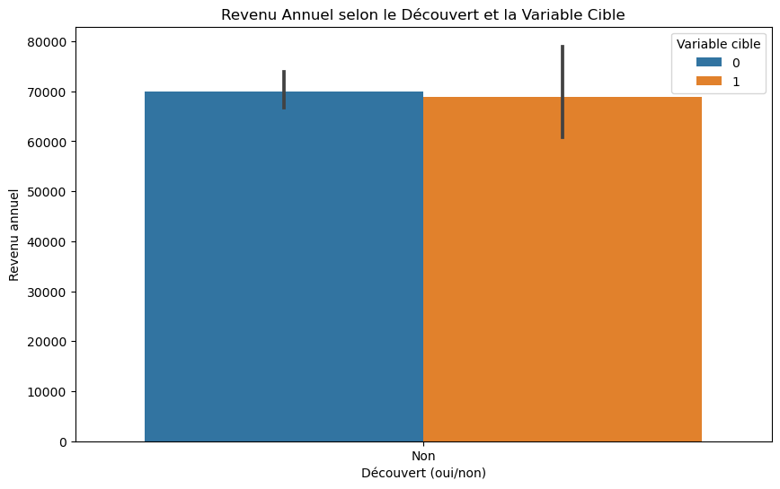

```python
# Étape 6 : Identification des Relations avec la Variable Cible
plt.figure(figsize=(10, 6))
sns.barplot(x='Découvert (oui/non)', y='Revenu annuel', hue='Variable cible', data=df)
plt.title('Revenu Annuel selon le Découvert et la Variable Cible')
plt.show()
```